# Prediction of personal activity in R

Mykyta Zharov

11/30/2019

## Overview

Using devices such as Jawbone Up, Nike FuelBand, and Fitbit it is possible to collect data about personal activity. People regularly quantify how much of a particular activity they do, but they rarely quantify how well they do it. 6 participants were asked to perform barbell lifts correctly and incorrectly in 5 different ways. In this project, the goal will be to use data from accelerometers on the belt, forearm, arm, and dumbell in order to predict the manner in which the participants did the exercise, using a “caret” package in R. The data for this project come from this source: http://groupware.les.inf.puc-rio.br/har.

- The training data for this project are available here: https://d396qusza40orc.cloudfront.net/predmachlearn/pml-training.csv
- The test data are available here: https://d396qusza40orc.cloudfront.net/predmachlearn/pml-testing.csv

Let us start by loading the data. Notice that we are specifying what values should be interpreted as NA’s.

```r
trainData <- read.csv(url("https://d396qusza40orc.cloudfront.net/predmachlearn/pml-training.csv"), na.strings=c("NA","#DIV/0!",""))
testData <- read.csv(url("https://d396qusza40orc.cloudfront.net/predmachlearn/pml-testing.csv"), na.strings=c("NA","#DIV/0!",""))
```

## Data cleaning

We want firstly to investigate our train data set.

```r
dim(trainData)
```

```
## [1] 19622   160
```

There are 160 variables in the train data set. Our goal is to predict “classe” variable using the other variables. We start with cleaning and preparing our train and test data sets for the analysis. Firslty, after observing the column names, we will delete first 7 columns, since they are uninformative for the prediction. Secondly, let us delete columns with missing values (NA’s), so that a model can be estimated.

```r
trainDataCleaned <- trainData[,8:length(colnames(trainData))]
testDataCleaned <- testData[,8:length(colnames(testData))]
```

```r
trainDataCleaned2 <- trainDataCleaned[, colSums(is.na(trainDataCleaned)) == 0]
testDataCleaned2 <- testDataCleaned[, (colnames(testDataCleaned) %in% colnames(trainDataCleaned2)) == TRUE]
```

This results in the following:

```r
str(trainDataCleaned2)
```

```
## 'data.frame':    19622 obs. of  53 variables:
##  $ roll_belt           : num  1.41 1.41 1.42 1.48 1.48 1.45 1.42 1.42 1.43 1.45 ...
##  $ pitch_belt          : num  8.07 8.07 8.07 8.05 8.07 8.06 8.09 8.13 8.16 8.17 ...
##  $ yaw_belt            : num  -94.4 -94.4 -94.4 -94.4 -94.4 -94.4 -94.4 -94.4 -94.4 -94.4 ...
##  $ total_accel_belt    : int  3 3 3 3 3 3 3 3 3 3 ...
##  $ gyros_belt_x        : num  0 0.02 0 0.02 0.02 0.02 0.02 0.02 0.02 0.03 ...
##  $ gyros_belt_y        : num  0 0 0 0 0.02 0 0 0 0 0 ...
##  $ gyros_belt_z        : num  -0.02 -0.02 -0.02 -0.03 -0.02 -0.02 -0.02 -0.02 -0.02 0 ...
##  $ accel_belt_x        : int  -21 -22 -20 -22 -21 -21 -22 -22 -20 -21 ...
##  $ accel_belt_y        : int  4 4 5 3 2 4 3 4 2 4 ...
##  $ accel_belt_z        : int  22 22 23 21 24 21 21 21 24 22 ...
##  $ magnet_belt_x       : int  -3 -7 -2 -6 -6 0 -4 -2 1 -3 ...
##  $ magnet_belt_y       : int  599 608 600 604 600 603 599 603 602 609 ...
##  $ magnet_belt_z       : int  -313 -311 -305 -310 -302 -312 -311 -313 -312 -308 ...
##  $ roll_arm            : num  -128 -128 -128 -128 -128 -128 -128 -128 -128 -128 ...
```

[output cut: 39 more lines]

Now we are ready to build and train predictive models using a cleaned train data set.

## Building predictive models

We are going to train 2 different predictive models (random forest, stochastic gradient boosting), compare them by accuracy and then try building a stacked model out of them.

### Test data set splitting

We devide the train data set into a train data set and validation data set, so than we than can evaluate the performance of the methods on the unseen data before applying the model on the test data set.

```r
library(caret)
in.training <- createDataPartition(trainDataCleaned2$classe, p=0.70, list=F)
trainSet <- trainDataCleaned2[in.training, ]
validateSet <- trainDataCleaned2[-in.training, ]
```

### Model training

```r
set.seed(123)
control.params <- trainControl(method="cv", 5)
#random forest
mod_rf <- train(classe ~ ., data = trainSet, method = "rf", trControl=control.params, ntree = 100)
#stochastic gradient boosting
mod_gbm <- train(classe ~ ., data = trainSet, method = "gbm", trControl=control.params, verbose = FALSE)
```

Now let us compare the performance of the trained models when using cross-validation for training.

```r
results <- resamples(list(RF=mod_rf,  GBM=mod_gbm))
summary(results)
```

```
##
## Call:
## summary.resamples(object = results)
##
## Models: RF, GBM
## Number of resamples: 5
##
## Accuracy
##          Min.  1st Qu.    Median      Mean   3rd Qu.      Max. NA's
## RF  0.9865308 0.989079 0.9890869 0.9892262 0.9901711 0.9912632    0
## GBM 0.9581666 0.959607 0.9599563 0.9624382 0.9639476 0.9705133    0
##
## Kappa
##          Min.   1st Qu.    Median      Mean   3rd Qu.      Max. NA's
## RF  0.9829587 0.9861878 0.9861936 0.9863709 0.9875641 0.9889501    0
## GBM 0.9470703 0.9489110 0.9493173 0.9524769 0.9543838 0.9627019    0
```

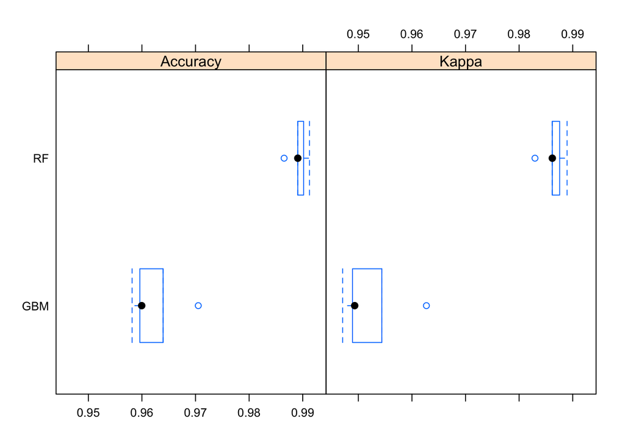

```r
# boxplots of results
bwplot(results)
```

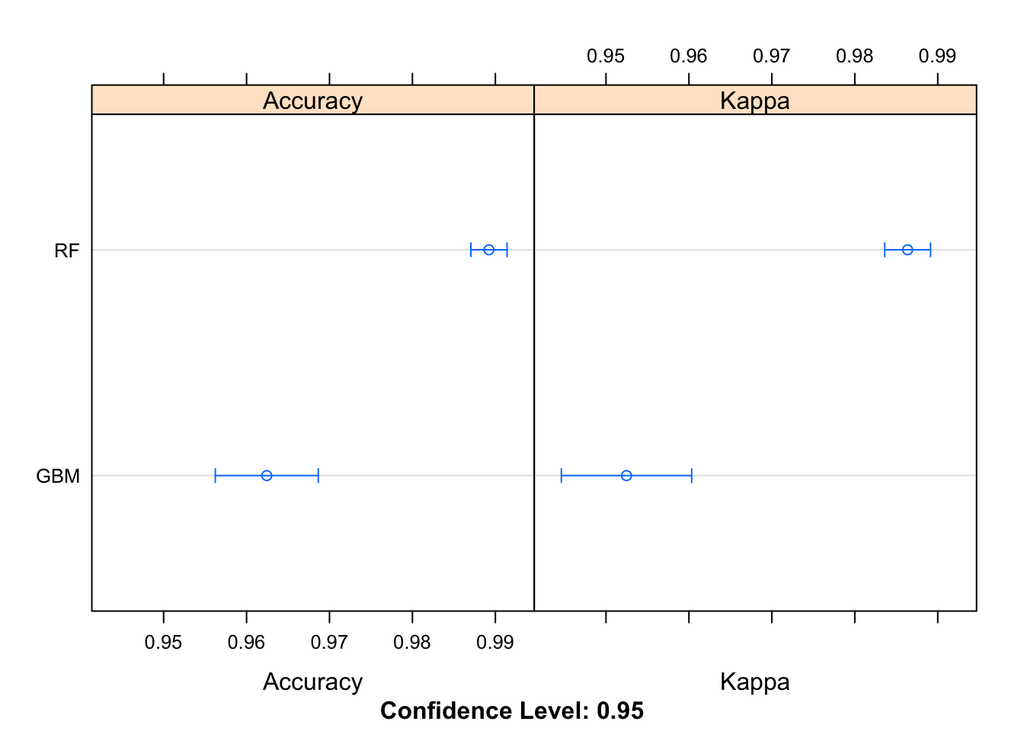

```r
# dot plots of results
dotplot(results)
```

From the the above output we observe that the Random Forest predictive model outperforms the Stochastic Gradient Boosting models when cross-validation is used for training. RF and GBM models have both quite high accuracy greater than 95%. Howewer, we would also like to expect the accuracy of the models on the unseen validation test to quantify an out-of-samle error.

### Model accuracy and out-of-samle error

Now, we are going to compare the 2 models on the unseen validation set.

```r
rf.predict <- predict(mod_rf, validateSet)
gbm.predict <- predict(mod_gbm, validateSet)

confusionMatrix(validateSet$classe, rf.predict)
```

```
## Confusion Matrix and Statistics
##
##           Reference
## Prediction    A    B    C    D    E
##          A 1669    4    1    0    0
##          B   13 1116    9    1    0
##          C    0    7 1016    3    0
##          D    0    0   15  949    0
##          E    0    0    0    2 1080
##
## Overall Statistics
##
##                Accuracy : 0.9907
##                  95% CI : (0.9879, 0.993)
##     No Information Rate : 0.2858
##     P-Value [Acc > NIR] : < 2.2e-16
##
##                   Kappa : 0.9882
##
##  Mcnemar's Test P-Value : NA
##
## Statistics by Class:
##
##                      Class: A Class: B Class: C Class: D Class: E
## Sensitivity            0.9923   0.9902   0.9760   0.9937   1.0000
## Specificity            0.9988   0.9952   0.9979   0.9970   0.9996
## Pos Pred Value         0.9970   0.9798   0.9903   0.9844   0.9982
## Neg Pred Value         0.9969   0.9977   0.9949   0.9988   1.0000
## Prevalence             0.2858   0.1915   0.1769   0.1623   0.1835
## Detection Rate         0.2836   0.1896   0.1726   0.1613   0.1835
## Detection Prevalence   0.2845   0.1935   0.1743   0.1638   0.1839
## Balanced Accuracy      0.9955   0.9927   0.9870   0.9953   0.9998
```

```r
confusionMatrix(validateSet$classe, gbm.predict)
```

```
## Confusion Matrix and Statistics
##
##           Reference
## Prediction    A    B    C    D    E
##          A 1651   16    4    3    0
##          B   40 1050   46    2    1
##          C    0   27  982   17    0
##          D    0    3   30  918   13
##          E    2   17    5   14 1044
##
## Overall Statistics
##
##                Accuracy : 0.9592
##                  95% CI : (0.9538, 0.9641)
##     No Information Rate : 0.2877
##     P-Value [Acc > NIR] : < 2.2e-16
##
##                   Kappa : 0.9484
##
##  Mcnemar's Test P-Value : 8.377e-07
##
## Statistics by Class:
##
##                      Class: A Class: B Class: C Class: D Class: E
## Sensitivity            0.9752   0.9434   0.9203   0.9623   0.9868
## Specificity            0.9945   0.9813   0.9909   0.9907   0.9921
## Pos Pred Value         0.9863   0.9219   0.9571   0.9523   0.9649
## Neg Pred Value         0.9900   0.9867   0.9825   0.9927   0.9971
## Prevalence             0.2877   0.1891   0.1813   0.1621   0.1798
## Detection Rate         0.2805   0.1784   0.1669   0.1560   0.1774
## Detection Prevalence   0.2845   0.1935   0.1743   0.1638   0.1839
## Balanced Accuracy      0.9849   0.9624   0.9556   0.9765   0.9894
```

Finally we want to build a stacked model out of 2 predictive models used above, and check if we obtain a better accuracy than using each model separately.

```r
predDF <- data.frame(rf.predict,  gbm.predict, classe = validateSet$classe)
combModFit <- train(classe ~ ., method = "rf", data = predDF, ntree=100)
combPred <- predict(combModFit, predDF)
confusionMatrix(validateSet$classe, combPred)
```

```
## Confusion Matrix and Statistics
##
##           Reference
## Prediction    A    B    C    D    E
##          A 1669    4    1    0    0
##          B   13 1116    9    1    0
##          C    0    7 1016    3    0
##          D    0    0   15  949    0
##          E    0    0    0    2 1080
##
## Overall Statistics
##
##                Accuracy : 0.9907
##                  95% CI : (0.9879, 0.993)
##     No Information Rate : 0.2858
##     P-Value [Acc > NIR] : < 2.2e-16
##
##                   Kappa : 0.9882
##
##  Mcnemar's Test P-Value : NA
##
## Statistics by Class:
##
##                      Class: A Class: B Class: C Class: D Class: E
## Sensitivity            0.9923   0.9902   0.9760   0.9937   1.0000
## Specificity            0.9988   0.9952   0.9979   0.9970   0.9996
## Pos Pred Value         0.9970   0.9798   0.9903   0.9844   0.9982
## Neg Pred Value         0.9969   0.9977   0.9949   0.9988   1.0000
## Prevalence             0.2858   0.1915   0.1769   0.1623   0.1835
## Detection Rate         0.2836   0.1896   0.1726   0.1613   0.1835
## Detection Prevalence   0.2845   0.1935   0.1743   0.1638   0.1839
## Balanced Accuracy      0.9955   0.9927   0.9870   0.9953   0.9998
```

## Applying final model on the test data set

Since we do not gain much in accuracy, using stacked model, in comparison to the Random Forest model, we choose to continue with RF model. Now we apply RF model on the test data set.

```r
results <- predict(mod_rf, newdata=testDataCleaned2)
results
```

```
##  [1] B A B A A E D B A A B C B A E E A B B B
## Levels: A B C D E
```

Above we can observe the classification results for the test data set.